# Main

### Problem 2.2 - Predicting the letters A, B, P, R

Now build a classification tree to predict “letter”, using the training set to build your model. You should use all of the other variables as independent variables, except “isB”, since it is related to what we are trying to predict! Just use the default parameters in your CART model. Add the argument method=“class” since this is a classification Problem. Even though we have multiple classes here, nothing changes in how we build the model from the binary case.

```r
CARTLetter <- rpart(letter~.-isB, data=train, method="class")

lubripack("rpart.plot")
```

```
##
## Bellow Packages Successfully Installed:
##
## rpart.plot
##       TRUE
```

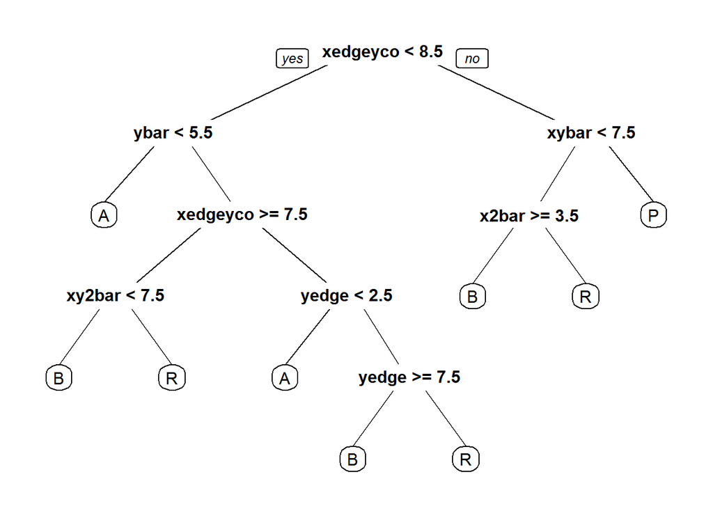

```r
prp(CARTLetter)
```

```r
Pred <- predict(CARTLetter,newdata = test, type = "class")

lubripack("dplyr")
```

```
##
## Bellow Packages Successfully Installed:
##
## dplyr
##  TRUE
```

```r
f <- as.matrix(table(test$letter,Pred)) %>% diag %>% sum
d <- sum(table(test$letter,Pred))

f/d
```

```
## [1] 0.8786906
```

What is the test set accuracy of your CART model? Use the argument type=“class” when making predictions.

(HINT: When you are computing the test set accuracy using the confusion matrix, you want to add everything on the main diagonal and divide by the total number of observations in the test set, which can be computed with nrow(test), where test is the name of your test set).

### Problem 2.3 - Predicting the letters A, B, P, R

Now build a random forest model on the training data, using the same independent variables as in the previous Problem – again, don’t forget to remove the isB variable. Just use the default parameter values for ntree and nodesize (you don’t need to include these arguments at all). Set the seed to 1000 right before building your model. (Remember that you might get a slightly different result even if you set the random seed.)

What is the test set accuracy of your random forest model?

```r
Letters_Forest <- randomForest(letter~.-isB, data=train)
letter_pred <- predict(Letters_Forest, newdata = test)
table(test$letter,letter_pred)
```

```
##    letter_pred
##       A   B   P   R
##   A 391   0   3   1
##   B   0 379   1   3
##   P   0   5 393   3
##   R   0  12   0 367
```

```r
f <- as.matrix(table(test$letter,letter_pred)) %>% diag %>% sum
d <- sum(table(test$letter,letter_pred))

f/d
```

```
## [1] 0.9820282
```

You should find this value rather striking, for several reasons. The first is that it is significantly higher than the value for CART, highlighting the gain in accuracy that is possible from using random forest models. The second is that while the accuracy of CART decreased significantly as we transitioned from the Problem of predicting B/not B (a relatively simple Problem) to the Problem of predicting the four letters (certainly a harder Problem), the accuracy of the random forest model decreased by a tiny amount.